# Innovative Data Exploration with LASSO: Unveiling Patterns in Earnings and Education

Author

Nikhitha Amireddy, Ishrath Jahan, Sai Kumar Miryala, Muhammad Usman Aslam

Published

April 23, 2024

Slides

## Introduction

LASSO, or Least Absolute Shrinkage and Selection Operator, is a refined linear regression method introduced by Robert Tibshirani in 1996 (Tibshirani 1996). This technique incorporates a penalty on the absolute values of regression coefficients, effectively reducing the risk of overfitting by eliminating less significant variables. LASSO’s ability to maintain model parsimony while enhancing interpretability makes it particularly valuable in handling large and complex datasets across various fields, including socioeconomic studies, public health, and environmental research (Zhao and Yu 2006; Fan and Lv 2011).

The development of LASSO has been influenced significantly by advancements such as Least Angle Regression (LARS) by Efron et al. (Efron et al. 2004), which further highlights the method’s capability in feature selection and regularization. This innovation has led to LASSO’s widespread adoption in disciplines requiring a clear interpretation of intricate data dynamics, such as economic forecasting and health diagnostics (T. Hastie, Tibshirani, and Friedman 2009; Belloni and Chernozhukov 2013).

Moreover, the integration of logistic regression with LASSO has opened new avenues for modeling categorical outcomes, enhancing the predictive accuracy and interpretability in various applications from epidemiology to finance (Simon and al. 2013; Li and al. 2022). As the complexity of datasets increases in the 21st century, LASSO remains a cornerstone in the toolkit of data scientists, aiding in the precise and simplified exploration of multifaceted data landscapes (Chintalapudi and al. 2022; Friedman, Hastie, and Tibshirani 2010).

## Literature Review

LASSO regression’s versatility across multiple fields illustrates its capability to manage complex datasets effectively, particularly with continuous outcomes. In the field of economics, Zhou et al. (2022)(Zhou and al. 2022) demonstrated LASSO’s effectiveness in isolating key economic predictors that are crucial for strategic decision-making. This application highlights its utility in economic analysis, where identifying factors that directly influence continuous outcomes like wages or economic growth is essential.

### Applications Across Fields

- **Economics**: Zhou et al. (2022)(Zhou and al. 2022) highlighted LASSO’s ability to identify key economic predictors that assist in strategic decision-making. This example underscores its utility in economic analysis, where it helps to isolate factors that directly influence continuous economic outcomes like wages, prices, or economic growth.
- **Bioinformatics**: Lu et al. (2011)(Yiming Lu 2011; Musoro 2014) used LASSO regression to develop models based on gene expression data, advancing our understanding of genetic influences on continuous traits and diseases. Their work illustrates how LASSO can handle vast amounts of biological data to pinpoint critical genetic pathways.
- **Environmental Science**: Wang et al. (2017)(Wang and al. 2017) applied LASSO to predict fuel consumption—a continuous variable—in maritime operations. This research supports sustainability efforts by providing precise predictions that help reduce environmental impact.
- **Public Health**: McEligot et al. (2020)(McEligot et al. 2020) employed logistic LASSO to explore how dietary factors, which vary continuously, affect the risk of developing breast cancer. Their findings highlight LASSO’s strength in dealing with complex, high-dimensional datasets in health sciences.

### Continuous Data Analysis

The consistent evolution of LASSO regression (Muthukrishnan and Rohini 2016; Friedman, Hastie, and Tibshirani 2010) reflects its increased adoption in fields that require robust statistical tools to analyze extensive and intricate data sets. Its effectiveness in managing continuous variables makes it particularly valuable in predictive modeling and data analysis.

### Model Optimization and Comparison

To ensure the accuracy and reliability of our LASSO regression model in predicting continuous wage outcomes, we implemented k-fold cross-validation(James et al. 2013). This technique is crucial for evaluating model performance on unseen data, helping to fine-tune the regularization parameter (lambda) which balances model complexity against predictive accuracy (T. Hastie, Tibshirani, and Friedman 2009).

Our comprehensive analysis underscores LASSO’s utility in producing models that are more parsimonious compared to MLR, particularly in scenarios with numerous predictors and potential overfitting (Tibshirani 1996). The results affirm the value of LASSO in modern statistical analysis and predictive modeling, as it enhances model interpretability and ensures robustness against the complexities inherent in large datasets.

## Methodology

### LASSO Regression

LASSO (Least Absolute Shrinkage and Selection Operator) regression, introduced by Robert Tibshirani in 1996, enhances traditional linear regression by adding a penalty for the size of the coefficients. This approach is particularly valuable in complex datasets with many potential predictors, some of which may not significantly influence the outcome. By penalizing the magnitude of the coefficients, LASSO helps in selecting only the most significant variables, simplifying the model and improving interpretability. (Tibshirani 1996)

### Mathematical Formulation

The **LASSO (Least Absolute Shrinkage and Selection Operator) regression** aims to create a model that balances the fit with its complexity, which helps in avoiding overfitting. The function is given by:

$$\min_{\beta} \left\{ \frac{1}{2n} \sum_{i=1}^{n} (y_i - \beta_0 - \sum_{j=1}^{p} \beta_j x_{ij})^2 + \lambda \sum_{j=1}^{p} |\beta_j| \right\}$$

#### Components of the Formula

###### 1. Beta Coefficients ($\beta$)

- These are the parameters of the model, where $\beta_0$ is the intercept, and $\beta_j$ are the coefficients for the predictors.

###### 2. Observed Values ($y_i$)

- These are the responses observed for each observation in the dataset.

###### 3. Predictor Values ($x_{ij}$)

- These are the values of the predictors for each observation.

###### 4. Residual Sum of Squares (RSS)

- It measures the discrepancies between observed values and predictions, normalized by $\frac{1}{2n}$ for computational convenience.

###### 5. Regularization Parameter ($\lambda$)

- This parameter controls the trade-off between fitting the model accurately and keeping the model coefficients small.

###### 6. L1 Penalty

- This term encourages the sparsity of the model by allowing some coefficients to shrink to zero.

##### Optimization Goal

The goal is to find coefficients that minimize the objective function, balancing between model accuracy and complexity.

##### Practical Implication

Adjusting $\lambda$ helps in controlling the model complexity and the number of predictors included in the model, making it simpler and possibly more interpretable.

### The Shrinkage Effect and Its Benefits

LASSO’s dual capability of coefficient shrinkage and feature selection is instrumental in our analysis:

- **Feature Selection**: In high-dimensional datasets, irrelevant predictors can obscure true relationships. LASSO counters this by reducing the coefficients of non-essential predictors to zero, thus highlighting the variables that genuinely impact the outcome. (Meinshausen and Bühlmann 2006)
- **Regularization**: This process helps in avoiding overfitting, making the model more generalizable and reliable for predicting new data. It is especially critical when dealing with complex models derived from large datasets. (T. Hastie, Tibshirani, and Friedman 2009)

### Role of the Regularization Parameter ($\lambda$)

Selecting an appropriate $\lambda$ is key:

- At $\lambda = 0$, LASSO equals an ordinary least squares regression, offering no coefficient shrinkage.
- Increasing $\lambda$ enhances the penalty, pushing more coefficients to zero, which simplifies the model and focuses on the most impactful variables.
- The optimal $\lambda$ is usually determined through cross-validation, ensuring the model strikes the right balance between bias and variance. (Friedman, Hastie, and Tibshirani 2010)

### Practical Application and Model Comparison

In practice, LASSO’s ability to discern key predictors makes it invaluable across various fields, including finance and healthcare, where precise models can significantly impact decision-making. Additionally, comparing LASSO with Multiple Linear Regression (MLR) illustrates its superiority in handling datasets with numerous predictors. While MLR provides a baseline by fitting data without regularization, LASSO advances this by selectively including only the most relevant variables, thereby preventing overfitting and enhancing the model’s predictive accuracy. (Park and Hastie 2008; Belloni and Chernozhukov 2013)

### Advantages of LASSO Regression

LASSO regression is highly valued in fields ranging from healthcare to finance due to its ability to simplify complex models without sacrificing accuracy. The method’s key strengths include:

- **Feature Selection**: LASSO can set some coefficients exactly to zero, effectively choosing the most relevant variables from many possibilities. This automatic feature selection helps focus the model on the truly impactful factors. (Park and Hastie 2008)
- **Model Interpretability**: By eliminating irrelevant variables, LASSO makes the resulting models easier to understand and communicate, enhancing their practical use. (Belloni and Chernozhukov 2013)
- **Mitigation of Multicollinearity**: LASSO addresses issues that arise when predictor variables are highly correlated. It selects one variable from a group of closely related variables, which simplifies the model and avoids redundancy. (Efron et al. 2004)

### Cross-Validation for Model Tuning

To ensure that our LASSO model performs well on new, unseen data, we used a technique called k-fold cross-validation. This approach tests the model’s effectiveness across different subsets of the dataset:

- **Methodology**: We divide the data into ‘k’ equal parts, or folds. The model is trained on ‘k-1’ of these folds, with the remaining part used as a test set. This process repeats so that each fold serves as a test set once, allowing us to use all data for both training and validation.
- **Optimization**: We calculate the cross-validation error for each value of the regularization parameter $\lambda$. This error is the average of the errors obtained from each fold and helps us find the best $\lambda$ that minimizes these errors:

$$CVE(\lambda) = \frac{1}{k} \sum_{i=1}^{k} MSE_i(\lambda)$$

Where $MSE_i(\lambda)$ represents the mean squared error on the ith fold. (Trevor Hastie, Tibshirani, and Wainwright 2015; Tibshirani 2021)

### Comparing LASSO Regression to Multiple Linear Regression

To highlight LASSO’s effectiveness, we compare it with Multiple Linear Regression (MLR), which models the relationship between a dependent variable and multiple predictors without regularization:

$$y = \beta_0 + \beta_1 x_1 + \beta_2 x_2 + \ldots + \beta_n x_n + \epsilon$$

MLR provides a baseline by estimating how each predictor affects the dependent variable, assuming all other variables are held constant. Here’s how MLR breaks down:

- **Intercept (**$\beta_0$): Represents the expected value of $y$ when all predictors are zero.
- **Coefficients (**$\beta_1, \beta_2, ..., \beta_n$): Each coefficient indicates the change in $y$ associated with a one-unit change in the respective predictor.
- **Error Term (**$\epsilon$): Captures the variability in $y$ not explained by the predictors.

In scenarios with high-dimensional data, LASSO’s ability to reduce some coefficients to zero provides a clear advantage over MLR. It simplifies the model, which can improve both interpretability and prediction accuracy, avoiding the common pitfalls of overfitting that MLR might suffer from.

## Analysis and Results

### Data Description

Understanding the variables in the `RetSchool` dataset is crucial for our analysis. These variables give us insights into the socio-economic and educational environment of 1976, helping us explore factors that influence wages and educational outcomes. Below is a table summarizing the key variables and their roles:

| Variable | Description | Type | Relevance |
| --- | --- | --- | --- |
| `wage76` | Wages of individuals in 1976 | Continuous | Primary measure of economic status, used to explore wage disparities. |
| `age76` | Age of individuals in 1976 | Continuous | Helps analyze the age distribution’s impact on wages. |
| `grade76` | Highest grade completed by 1976 | Continuous | Indicates educational attainment and its correlation with economic success. |
| `col4` | Whether individuals received college education by 1976 | Binary | Differentiates the impact of higher education on wages. |
| `exp76` | Years of work experience by 1976 | Continuous | Examines how work experience influences wages. |
| `momdad14` | Whether lived with both parents at age 14 | Binary | Assesses the impact of family structure on early life outcomes. |
| `sinmom14` | Whether lived with a single mother at age 14 | Binary | Similar to `momdad14`, focuses on single-mother households. |
| `daded` | Education level of father | Continuous | Explores how paternal education affects offspring’s outcomes. |
| `momed` | Education level of mother | Continuous | Similar to `daded`, but focuses on maternal education. |
| `black` | Whether individuals are identified as black | Binary | Used to analyze racial disparities within the dataset. |
| `south76` | Whether individuals resided in the South in 1976 | Binary | Important for regional economic analysis. |
| `region` | Geographic region classification | Categorical | Enhances the analysis of regional influences on outcomes. |
| `smsa76` | Residence within a Standard Metropolitan Statistical Area in 1976 | Binary | Relevant for examining urban versus rural disparities. |

This table categorizes the variables based on their type and relevance to our study, setting the stage for a detailed exploration of how these factors interplay to shape economic outcomes during the mid-1970s.

**Data Exploration**

Initial exploration of the `RetSchool` dataset revealed a diverse range of variables, necessitating meticulous data cleaning to ensure accuracy in our subsequent analyses. Missing values were addressed through imputation or removal, refining our dataset for a comprehensive examination.

```r
knitr::opts_chunk$set(echo = TRUE, message = FALSE, warning = FALSE, results = 'hide')
library(tidyverse)
library(ggplot2)
library(corrplot)
library(gridExtra)
df <- read_csv("https://vincentarelbundock.github.io/Rdatasets/csv/Ecdat/RetSchool.csv", show_col_types = FALSE)
```

### Distribution of Key Variables

### Work Experience Distribution

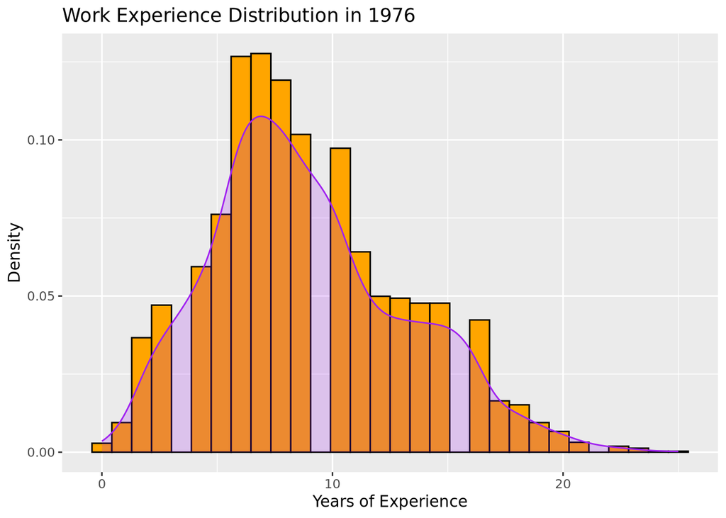

Figure 1: Work Experience Distribution in 1976

```r
library(ggplot2)
# Generate the plot
p_experience <- ggplot(df, aes(x = exp76)) +
  geom_histogram(aes(y = ..density..), bins = 30, fill = "orange", color = "black") +
  geom_density(color = "purple", fill = "purple", alpha = 0.2) +
  labs(title = "Work Experience Distribution in 1976", x = "Years of Experience", y = "Density")
p_experience
```

```r
# Save the plot as an image
ggsave("p_experience.png", plot = p_experience, width = 10, height = 5, dpi = 300)
```

The right-skewed distribution of `exp76` in the `RetSchool` dataset indicates a predominantly young and less experienced workforce in 1976. This skewness suggests a workforce that was entering or early in their careers. For more details, see Figure 1: Work Experience Distribution in 1976 the distribution of work experience in 1976 indicates a predominantly young workforce:

#### Wage Distribution Analysis

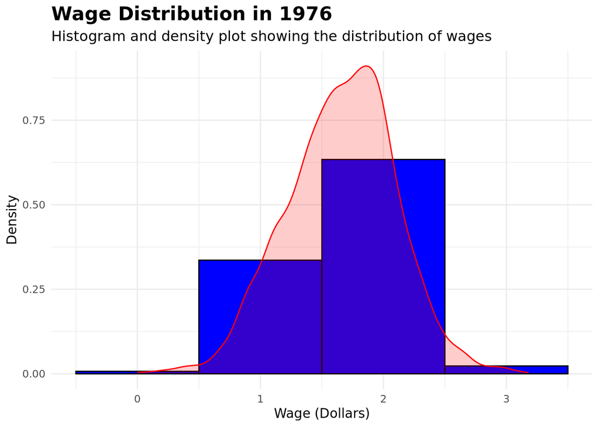

Figure 2: Wage Distribution in 1976

```r
p_wage <- ggplot(df, aes(x = wage76)) +
  geom_histogram(aes(y = ..density..), binwidth = 1, fill = "blue", color = "black") +
  geom_density(color = "red", fill = "red", alpha = 0.2) +
  labs(title = "Wage Distribution in 1976",
       x = "Wage (Dollars)",
       y = "Density",
       subtitle = "Histogram and density plot showing the distribution of wages") +
  theme_minimal() +
  theme(plot.title = element_text(size = 16, face = "bold"),
        plot.subtitle = element_text(size = 12))
p_wage
```

```r
ggsave("p_wage.png", plot = p_wage, width = 10, height = 5, dpi = 300)
```

The histogram and density plot for `wage76` reveal the distribution of wages among workers in 1976, showing a typical pattern that indicates economic inequalities Figure 2: Wage Distribution in 1976:

#### Correlation Matrix

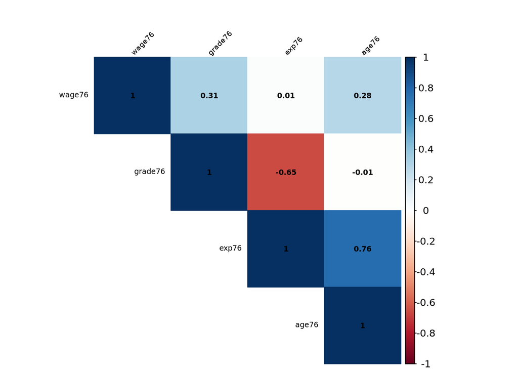

Figure 3: Correlation Matrix of Selected Variables

**Why LASSO for the RetSchool Dataset?**

### Understanding Wages as a Continuous Variable

Through our LASSO analysis, we also confirmed that `wage76`, our main variable of interest, is continuous. This was evident as LASSO helped highlight the relationships between wages and various predictors without breaking them into arbitrary categories, preserving the natural continuous scale of wage data. This continuous perspective is crucial for accurate modeling and meaningful conclusions about how various factors influence wages.

Given these strengths, LASSO regression is an ideal choice for navigating the complexities of the RetSchool dataset, providing a clear, robust model that is well-suited for making informed decisions on wage policy and understanding the economic landscape of 1976.

## Statistical Modeling

### Data Preparation

Before we start analyzing with our LASSO regression model, it’s important to prepare our data properly. Good data leads to good analysis, which means our findings will be more reliable.

#### Data Cleaning and Imputation

Our dataset, called RetSchool, needs some tidying up to make sure our model works well. Here’s what we did:

- **Handling Missing Data**: Some important information like educational background (`grade76`) and work experience (`exp76`) were missing in some records. We filled these gaps using the median of each variable, because the median is good at dealing with data that has outliers.
- **Removing Incomplete Records**: Even after filling in some missing values, some data was still incomplete. We decided to remove these records to keep our analysis strong and accurate.

This cleaning makes sure our dataset is solid, without any misleading gaps or errors that could twist our results.

#### Visualization of Data Cleaning

To show how our cleaning efforts have improved the dataset, we would normally visualize the distribution of important variables before and after the cleaning. This visual check helps us see the effect of our preparations and ensures the data quality is up to mark for further analysis.

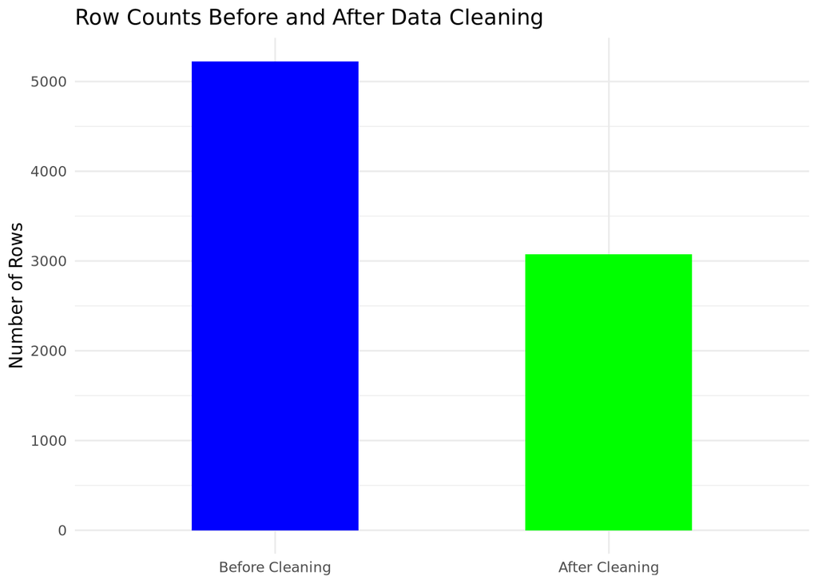

```r
library(tidyverse)
library(ggplot2)
library(gridExtra)

# Load data
df <- read_csv("RetSchool.csv", show_col_types = FALSE)

# Record initial number of rows
initial_count <- nrow(df)

# Data Cleaning
df_clean <- df %>%
  mutate(
    grade76 = ifelse(is.na(grade76), median(grade76, na.rm = TRUE), grade76),
    exp76 = ifelse(is.na(exp76), median(exp76, na.rm = TRUE), exp76)
  ) %>%
  na.omit()

# Record cleaned number of rows
cleaned_count <- nrow(df_clean)

# Data frame for visualization
counts_df <- tibble(
  Stage = factor(c("Before Cleaning", "After Cleaning"), levels = c("Before Cleaning", "After Cleaning")),
  Rows = c(initial_count, cleaned_count)
)

# Visualize row counts before and after cleaning
p_row_counts <- ggplot(counts_df, aes(x = Stage, y = Rows, fill = Stage)) +
  geom_bar(stat = "identity", width = 0.5, show.legend = FALSE) +
  scale_fill_manual(values = c("blue", "green")) +
  labs(title = "Row Counts Before and After Data Cleaning", x = NULL, y = "Number of Rows") +
  theme_minimal()

# Print the plot
print(p_row_counts)
```

### Selection of Target and Predictor Variables

#### Understanding the Research Focus

The core objective of our study using the RetSchool dataset is to explore the factors that influenced wage disparities in 1976. This objective guides our selection of the target and predictor variables, focusing on elements that potentially affect economic outcomes of that period.

#### Target Variable

- **Wage (`wage76`)**: The primary variable of interest, `wage76`, represents the wages earned by individuals in 1976. It is chosen as the target variable because it directly quantifies economic compensation, making it essential for analyzing wage disparities. This variable’s role is to serve as the response in our LASSO regression model, helping us understand how various factors might influence earnings during the studied period.

```r
# Assuming df_clean is your cleaned dataset
y <- df_clean$wage76
```

#### Predictor Variables

A set of predictors has been selected based on their theoretical relevance to wage determination:

- **Educational Background (`grade76`, `col4`)**: These predictors are expected to impact wages significantly, as higher educational attainment is commonly associated with higher income levels.
- **Work Experience (`exp76`)**: The number of years of work experience is included as a predictor under the assumption that more experience typically correlates with higher wages.
- **Demographic and Regional Factors**: Variables such as age, race, and geographic location are included to assess their impact on wages, acknowledging that socio-economic diversity and regional economic conditions play crucial roles in wage determination.

#### Visualizing Key Variables

With the data now clean and the variables of interest identified, visualizing these can provide deeper insights into their distribution and relationships within the dataset. This helps in understanding the dynamics and potential influences on wages in 1976 Figure 4:Visualizations of Key Variables.

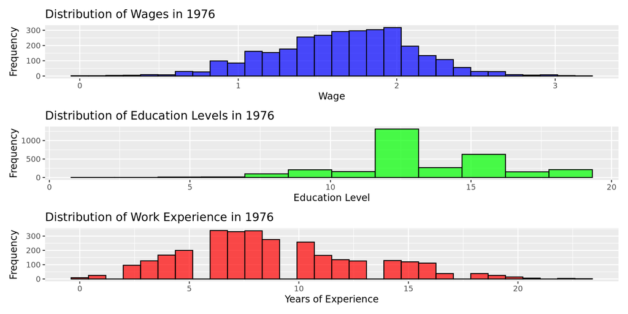

Figure 4: Visualizations of Key Variables

```r
library(ggplot2)
library(patchwork)

# Wage Distribution
p_wage <- ggplot(df_clean, aes(x = wage76)) +
  geom_histogram(bins = 30, fill = "blue", color = "black", alpha = 0.7) +
  labs(title = "Distribution of Wages in 1976", x = "Wage", y = "Frequency")

# Education Distribution
p_education <- ggplot(df_clean, aes(x = grade76)) +
  geom_histogram(bins = 12, fill = "green", color = "black", alpha = 0.7) +
  labs(title = "Distribution of Education Levels in 1976", x = "Education Level", y = "Frequency")

# Experience Distribution
p_experience <- ggplot(df_clean, aes(x = exp76)) +
  geom_histogram(bins = 30, fill = "red", color = "black", alpha = 0.7) +
  labs(title = "Distribution of Work Experience in 1976", x = "Years of Experience", y = "Frequency")

# Combine plots using patchwork
d_plot <- p_wage + p_education + p_experience + plot_layout(ncol = 1)

# Display the combined plot
d_plot
```

```r
# Save the combined plot
ggsave("d_plot.png", plot = d_plot, width = 10, height = 5, dpi = 300)
```

### Why LASSO Regression?

Transitioning from variable selection to modeling, it is essential to choose a regression technique that effectively handles the intricacies of our dataset. LASSO regression stands out as a particularly apt choice for several reasons:

#### Suitability of LASSO Regression

Given the complexity of the RetSchool dataset, which includes a variety of predictors with potential multicollinearity and overfitting issues, LASSO regression is an ideal choice. LASSO’s capability to perform variable selection and regularization simultaneously allows us to focus on the most impactful predictors while reducing overfitting, enhancing both the interpretability and accuracy of our model.

LASSO is especially beneficial in scenarios where the number of predictors is large in comparison to the number of observations, or when certain predictors are highly correlated with each other. By penalizing the absolute size of the regression coefficients, LASSO helps in:

- **Reducing Model Complexity**: It simplifies the model by shrinking less important variable’s coefficients to zero, thus effectively selecting a simpler model that avoids overfitting.
- **Enhancing Interpretability**: Models with fewer variables are easier to understand and communicate, which is crucial for making actionable insights.

#### Preparing for LASSO Regression

Before implementing LASSO, it is crucial to scale the features due to LASSO’s sensitivity to the scale of input variables. Feature scaling ensures that the regularization penalty is applied uniformly across all predictors.

##### Feature Scaling

Feature scaling is a critical preparatory step in our analysis, essential for the application of LASSO regression. LASSO’s approach to regularization is sensitive to the scale of variables, as it penalizes the absolute size of the regression coefficients. This sensitivity can lead to disproportionate influence from variables with larger numeric ranges, skewing the model and potentially leading to misleading conclusions about the factors influencing wages.

```r
library(caret)
library(glmnet)

# Selecting only numeric features and excluding the target variable 'wage76'
numeric_features <- select(df_clean, where(is.numeric), -wage76)

# Converting the selected features into a matrix, as required by glmnet
features <- data.matrix(numeric_features)
preProcValues <- preProcess(features, method = c("center", "scale"))
features_scaled <- predict(preProcValues, features)
```

**Demonstrating the Impact of Feature Scaling** We focus specifically on scaling `exp76`—years of experience—because it is a key predictor of wages, which is our continuous outcome variable. Proper scaling is vital to fairly assess how work experience impacts wages, alongside other factors such as education and demographic variables.

To illustrate the importance of this process, consider the variable `exp76`. Before scaling, `exp76` might display a wide range of values that reflect the diverse work experiences in our dataset. However, without scaling, this range could disproportionately affect the LASSO model’s ability to apply regularization fairly across all predictors Figure 5: Distribution of Feature ‘exp76’ Before and After Scaling.

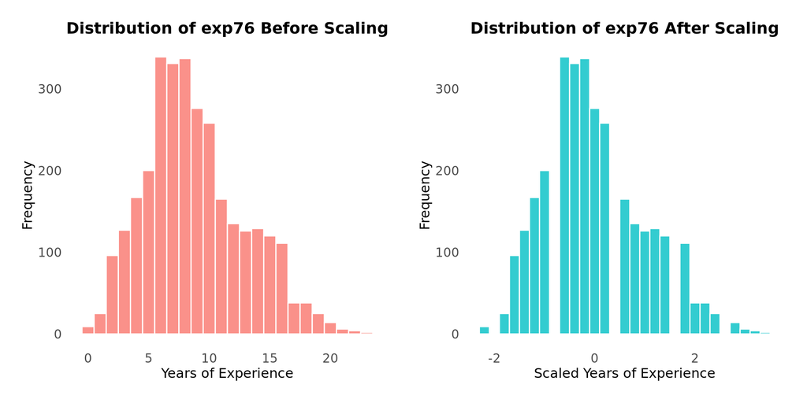

Figure 5: Distribution of Feature ‘exp76’ Before and After Scaling

```r
library(ggplot2)
library(gridExtra)  # Ensure this package is installed for plot_layout

# Selecting a feature for comparison
feature_name <- "exp76"  # Example feature

# Plotting the distribution before scaling
p_before_scaling <- ggplot(df_clean, aes(x = get(feature_name))) +  # Using get() for dynamic variable name
  geom_histogram(binwidth = 1, fill = "#F8766D", color = "#FFFFFF", alpha = 0.8) +
  labs(title = paste("Distribution of", feature_name, "Before Scaling"),
       x = "Years of Experience",
       y = "Frequency") +
  theme_minimal() +
  theme(plot.title = element_text(size = 14, face = "bold", hjust = 0.5),
        axis.title.x = element_text(size = 12),
        axis.title.y = element_text(size = 12),
        axis.text.x = element_text(size = 11),
        axis.text.y = element_text(size = 11),
        panel.grid.major = element_blank(),
        panel.grid.minor = element_blank(),
        plot.margin = unit(c(1, 1, 1, 1), "lines"))  # Increase margins around the plot

# Extracting the scaled values for the selected feature
scaled_feature <- features_scaled[, feature_name]

# Plotting the distribution after scaling
p_after_scaling <- ggplot(data.frame(scaled_feature = scaled_feature), aes(x = scaled_feature)) +
  geom_histogram(binwidth = 0.2, fill = "#00BFC4", color = "#FFFFFF", alpha = 0.8) +
  labs(title = paste("Distribution of", feature_name, "After Scaling"),
       x = "Scaled Years of Experience",
       y = "Frequency") +
  theme_minimal() +
  theme(plot.title = element_text(size = 14, face = "bold", hjust = 0.5),
        axis.title.x = element_text(size = 12),
        axis.title.y = element_text(size = 12),
        axis.text.x = element_text(size = 11),
        axis.text.y = element_text(size = 11),
        panel.grid.major = element_blank(),
        panel.grid.minor = element_blank(),
        plot.margin = unit(c(1, 1, 1, 1), "lines"))  # Maintain consistent margins

# Combine the plots side by side
combined_plot <- p_before_scaling + p_after_scaling + plot_layout(ncol = 2)
print(combined_plot)
```

```r
ggsave("combined_plot.png", plot = combined_plot, width = 10, height = 5, dpi = 300)
```

After scaling, `exp76` is transformed to have a standard scale similar to other variables in the model. This normalization allows for a fair comparison and interaction within the model, ensuring that no single variable unduly influences the outcome due to its scale.

The transformation that occurs when features like `exp76` are normalized is pivotal for models like LASSO regression, which rely on regularization techniques sensitive to the scale of input variables. By ensuring that the regularization penalty is applied uniformly across all features, scaling enhances the model’s ability to identify truly significant predictors and avoids undue influence from variables simply because of their scale.

This step is crucial for maintaining the integrity and accuracy of our analysis, particularly in studies focused on understanding continuous outcomes such as wage disparities, where the precise quantification of each variable’s impact is essential.

**Visualizing the Impact of (**$\lambda$) on Model Performance

The regularization parameter ($\lambda$) in LASSO regression critically influences model accuracy by balancing model complexity and predictive performance. Selecting the optimal ($\lambda$) is essential to minimize overfitting and ensure the model generalizes well Figure 6: Cross-Validation CurveFigure 6: Cross-Validation Curve.

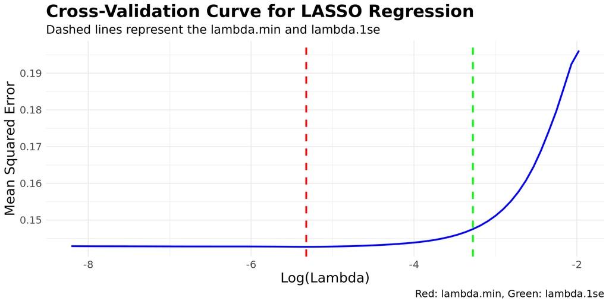

Figure 6: Cross-Validation Curve

```r
library(glmnet)
library(ggplot2)
library(dplyr)

# Define the response variable y
y <- df_clean$wage76
set.seed(123) # For reproducibility
cv_outcome <- cv.glmnet(features_scaled, y, alpha = 1, nfolds = 10)

# Creating a data frame from the glmnet cross-validation output
cv_data <- as.data.frame(cv_outcome$cvm)
names(cv_data) <- c("mse")
cv_data$lambda <- log(cv_outcome$lambda)
cv_data$lambda_min <- log(cv_outcome$lambda.min)
cv_data$lambda_1se <- log(cv_outcome$lambda.1se)

# Plotting with ggplot2
Cross_Validation_plot <- ggplot(cv_data, aes(x = lambda, y = mse)) +
  geom_line(color = "blue", linewidth = 1) +
  geom_vline(xintercept = cv_data$lambda_min, linetype = "dashed", color = "red", linewidth = 1) +
  geom_vline(xintercept = cv_data$lambda_1se, linetype = "dashed", color = "green", linewidth = 1) +
  labs(title = "Cross-Validation Curve for LASSO Regression",
       subtitle = "Dashed lines represent the lambda.min and lambda.1se",
       x = "Log(Lambda)",
       y = "Mean Squared Error",
       caption = "Red: lambda.min, Green: lambda.1se") +
  theme_minimal() +
  theme(plot.title = element_text(size = 20, face = "bold"),
        plot.subtitle = element_text(size = 14),
        plot.caption = element_text(size = 12),
        axis.title = element_text(size = 16),
        axis.text = element_text(size = 12))
Cross_Validation_plot
```

```r
ggsave("Cross_Validation_plot.png", plot = Cross_Validation_plot, width = 10, height = 5, dpi = 300)
```

##### Role of Cross-Validation in Determining ($\lambda$)

Cross-validation is essential for selecting the right ($\lambda$) in LASSO regression. It helps balance the model by preventing overfitting with low ($\lambda$) values and underfitting with high ($\lambda$) values. This method splits the data into subsets, testing how each ($\lambda$) performs, thus ensuring the model’s effectiveness on new, unseen data.

##### Optimal ($\lambda$) Choices

Cross-validation identifies crucial ($\lambda$) values for optimal model performance:

- **Optimal (**$\lambda$) (`lambda.min`): Achieves the lowest mean squared error (MSE), indicating the best balance between accuracy and complexity.
- **Conservative (**$\lambda$) (`lambda.1se`): Slightly higher than `lambda.min`, it provides a simpler model that is robust and stable, useful for generalizing well to new data.

### Model Coefficients and Interpretation

The optimized LASSO model clearly delineates which factors significantly impact wages, simplifying the analysis by reducing less impactful predictors. This streamlined approach not only enhances interpretability but also focuses on the most influential variables affecting wages in 1976.

Figure 7: Visualization of LASSO Coefficients visualizes these coefficients, highlighting the relative importance of each predictor in the context of wage determination.

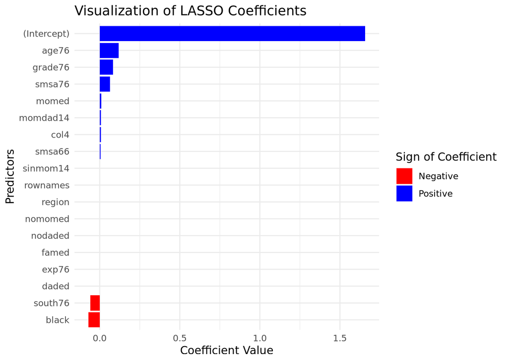

Figure 7: Visualization of LASSO Coefficients

```r
library(knitr)
library(glmnet)

# Ensure the cv_outcome object is available and correctly specified
if (exists("cv_outcome")) {
  # Extract coefficients using a safe method
  coef_optimal <- tryCatch({
    coef(cv_outcome, s = "lambda.min", exact = FALSE)
  }, error = function(e) {
    message("Failed to extract coefficients: ", e$message)
    NULL  # Return NULL if there's an error
  })

  if (!is.null(coef_optimal) && inherits(coef_optimal, "dgCMatrix")) {
    # Convert the matrix to a data frame for better handling
    coef_matrix <- as.matrix(coef_optimal)
    coef_df <- as.data.frame(coef_matrix, stringsAsFactors = FALSE)
    coef_df$Variable <- rownames(coef_matrix)  # Add variable names as a new column
    rownames(coef_df) <- NULL  # Clean up row names

    # Rename the coefficient column for clarity
    names(coef_df)[1] <- "Coefficient"
    cv_outcome_plot <- ggplot(coef_df, aes(x = reorder(Variable, Coefficient), y = Coefficient, fill = Coefficient > 0)) +
        geom_col() +
        coord_flip() +  # Makes the plot horizontal for better readability
        labs(title = "Visualization of LASSO Coefficients", x = "Predictors", y = "Coefficient Value") +
        scale_fill_manual(values = c("red", "blue"), name = "Sign of Coefficient",
                          labels = c("Negative", "Positive")) +
        theme_minimal()
    cv_outcome_plot
  } else {
    message("Coefficient data is not available or invalid.")
  }
} else {
  message("cv_outcome is not available. Please check model fitting.")
}
```

**Significant Predictors and Their Effects**

The LASSO model has highlighted key factors that influence wages, efficiently pinpointing the most impactful variables:

- **Baseline Wages**: The intercept sets the starting point for wage predictions, adjusted for average levels of predictors.
- **Educational Attainment (`grade76`)**: Higher education levels are strongly associated with increased wages, confirming the significant return on investment in education.
- **Racial Disparity (`black`)**: There is a noticeable wage gap affecting black individuals, indicating persistent racial inequalities in earnings.
- **Geographic Influence (`south76`)**: Residing in the South is linked to lower wages, reflecting regional economic differences.
- **Urban Premium (`smsa76`)** and **Long-term Urban Advantage (`smsa66`)**: Both highlight the wage benefits of living in urban areas, both currently and historically.
- **Family Stability (`momdad14`)**: Growing up with both parents is correlated with higher wages, suggesting the economic benefits of a stable family during childhood.
- **Parental Education (`momed`)**: Higher maternal education levels positively affect wages, underscoring the influence of parental education.
- **Age and Experience (`age76`)**: Older age, often accompanied by more experience, typically leads to higher wages, reflecting the value of longevity in the workforce.
- **Higher Education (`col4`)**: Possessing a college degree shows a positive but modest correlation with higher wages.

**Variables with Minimal Impact**

Several variables demonstrated minimal to no influence on wages, exemplifying Lasso’s ability to streamline the model by eliminating non-impactful predictors. These include `exp76`, `region`, `sinmom14`, `nodaded`, `nomomed`, `daded`, and `famed`. This reduction in variables enhances the interpretability of our model without compromising the accuracy of our predictions.

## Results & Conclusion

### Explaining the Linear Relationship between the target variables and predictors

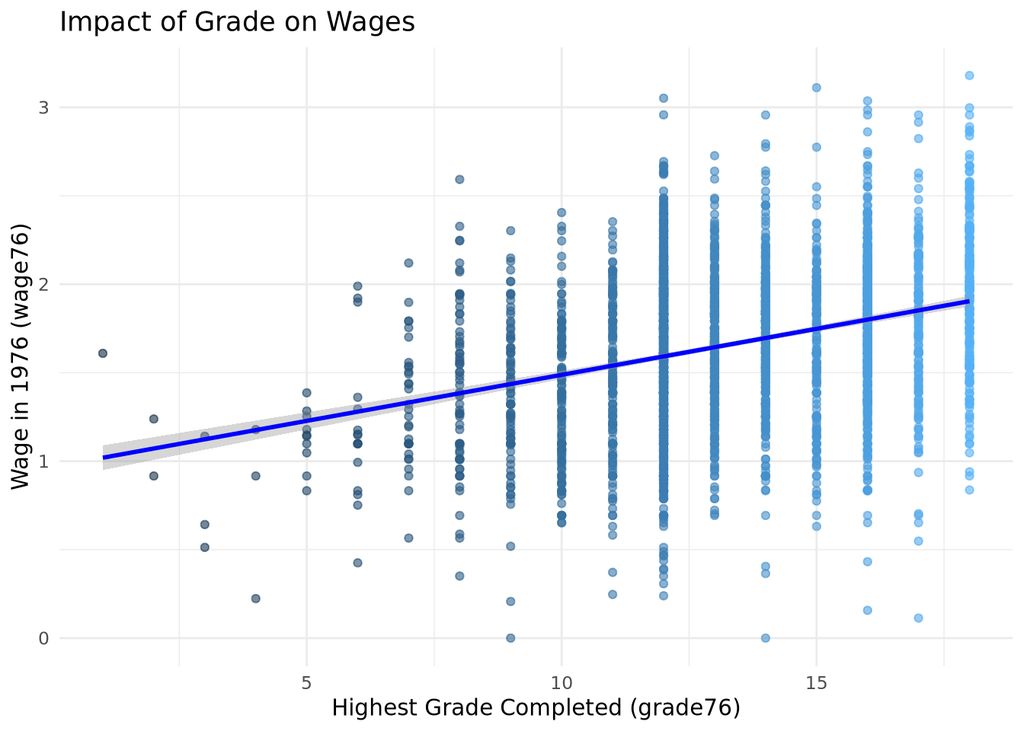

```r
library(ggplot2)

# Plotting wage76 against grade76 with a linear regression line
plot_grade76 <- ggplot(df_clean, aes(x = grade76, y = wage76)) +
  geom_point(aes(color = grade76), alpha = 0.6) +  # Color points by grade76 for additional visual differentiation
  geom_smooth(method = "lm", color = "blue", se = TRUE) +  # Add linear regression line with confidence interval
  labs(title = "Impact of Grade on Wages",
       x = "Highest Grade Completed (grade76)",
       y = "Wage in 1976 (wage76)") +
  theme_minimal() +
  theme(legend.position = "none")  # No need for a legend in this context

# Print the plot
print(plot_grade76)
```

Graph 1: Impact of Grade on Wages

Graph 1 clearly explains the linear relationship for the wages(target variable) and grade76(predictor)

### Comparative Analysis of Coefficient Impact

Our analysis with the LASSO model has effectively highlighted the most significant factors influencing wages, using a method that focuses on simplicity and accuracy by penalizing less impactful predictors. However, to deepen our understanding of these results, we also employed Multiple Linear Regression (MLR) as a comparative tool. This step allows us to observe the differences in how each model handles the complexity of the dataset and the continuous nature of the wage variable.

```r
library(glmnet)
library(caret)
library(knitr)
library(kableExtra)

# Ensure df_clean is prepared as earlier described
df_clean <- read_csv("RetSchool.csv", show_col_types = FALSE) %>%
  mutate(grade76 = ifelse(is.na(grade76), median(grade76, na.rm = TRUE), grade76),
         exp76 = ifelse(is.na(exp76), median(exp76, na.rm = TRUE), exp76)) %>%
  na.omit()

# Fitting Multiple Linear Regression (MLR)
model_mlr <- lm(wage76 ~ ., data = df_clean)
# Extract coefficients from the MLR model
coefficients_mlr <- coef(model_mlr)

# Fitting LASSO model
set.seed(123)  # for reproducibility
features_scaled <- as.matrix(df_clean[setdiff(names(df_clean), "wage76")])
cv_outcome <- cv.glmnet(features_scaled, df_clean$wage76, alpha = 1)

# Extracting coefficients from the LASSO model using predict with s="lambda.min"
lasso_coefs <- predict(cv_outcome, type="coefficients", s = "lambda.min")[1:ncol(features_scaled),,drop=FALSE]

# Filter non-zero coefficients
non_zero_lasso <- lasso_coefs[lasso_coefs[,1] != 0, , drop=FALSE]

# Align MLR coefficients with non-zero LASSO coefficients
non_zero_names <- rownames(non_zero_lasso)
matching_mlr_coefs <- coefficients_mlr[non_zero_names]

# Create a data frame for comparison
coefficients_comparison <- data.frame(
  Predictor = non_zero_names,
  Coefficient_MLR = as.numeric(matching_mlr_coefs),
  Coefficient_LASSO = as.numeric(non_zero_lasso)
)

# Display the comparison using knitr
kable(coefficients_comparison, format = "html", caption = "Comparison of MLR and LASSO Coefficients", align = 'c') %>%
  kable_styling(bootstrap_options = c("striped", "hover", "condensed"), full_width = F, font_size = 12) %>%
  scroll_box(width = "100%", height = "500px")
```

[output not shown]

Comparing LASSO to MLR provides several benefits:

- **Baseline Comparison**: MLR, which does not include a regularization term, serves as a baseline to appreciate how much LASSO’s penalties affect the coefficients of each predictor.
- **Insight into Overfitting**: By observing how predictors behave in MLR, which is prone to overfitting especially in datasets with many variables, we can better understand the necessity and effectiveness of LASSO’s regularization approach.
- **Variable Importance**: This comparison clearly delineates which variables are genuinely important for predicting wages, as significant predictors in MLR that are penalized to zero in LASSO may not be as crucial as initially thought.

### Significant Predictors of Wages

- **Consistency and Differences**: Where LASSO might zero out a predictor, MLR may still attribute it with a significant coefficient. Such differences are key in understanding the potential for overfitting in MLR versus the more conservative and potentially more reliable predictions from LASSO.
- **Focus on Continuous Outcomes**: Both models emphasize the importance of continuous predictors like `age76` and `grade76`, but LASSO does so while maintaining model parsimony, avoiding the pitfalls of including too many variables as MLR might.

**Visual Comparison of Model Outcomes**

Visualizing the differences between the coefficients in Multiple Linear Regression (MLR) and LASSO offers a clear, intuitive understanding of how regularization in LASSO affects each predictor’s influence compared to traditional regression methods.

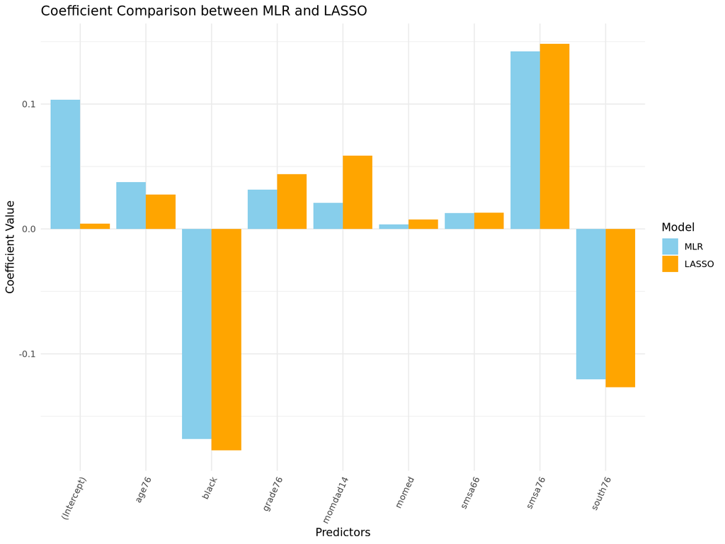

Figure 8: Comparison of Coefficients from MLR and LASSO

The chart below, titled “Figure 8: Comparison of Coefficients from MLR and LASSO,” illustrates how LASSO’s regularization alters the coefficients:

-**Selective Feature Retention**: LASSO may reduce some predictors’ coefficients to zero—effectively removing them from the model—if they are not statistically significant. This feature selection is critical in complex datasets like RetSchool, where simplifying the model can lead to clearer, more actionable insights.

-**Stability Across Models**: Predictors whose coefficients are consistent across both MLR and LASSO are likely very reliable indicators of wage variations, underscoring their importance regardless of the modeling approach used.

-**Enhanced Interpretability**: LASSO improves the model’s clarity by focusing only on significant predictors. This makes it easier for analysts and decision-makers to understand which factors truly influence wages, facilitating more informed decisions.

#### Advantages of LASSO Over MLR in Educational Data Analysis

In the context of the RetSchool dataset, which explores factors influencing educational returns in the labor market, LASSO offers several distinct advantages:

-**Effective Feature Selection**: Unlike MLR, which might incorporate every predictor into the analysis, LASSO strategically eliminates less relevant variables. This focus helps distill the model to the most impactful factors, reducing complexity and improving the clarity of results.

-**Managing Multicollinearity**: LASSO addresses the challenge of multicollinearity common in educational data, where variables such as years of education, urban residency, and parental background might be interrelated. By penalizing coefficients, LASSO minimizes redundant information, ensuring that each included predictor contributes uniquely to understanding wage disparities.

-**Improving Model Interpretability**: The simplification LASSO brings allows stakeholders to better understand the dynamics within the data. For example, it becomes clearer how factors like education level, race, and geographic location impact wages independently of each other.

### Conclusion and Insights from the Return to School Dataset

Our application of LASSO regression has uncovered significant factors that influenced wages in 1976, notably highlighting how educational attainment and age directly impact earnings. These findings not only confirm the importance of these predictors but also help us understand the extent to which they affect wage disparities.

#### Key Insights:

- **Educational Impact on Earnings**: Higher educational levels consistently lead to increased wages, affirming that education is a crucial investment with substantial returns.
- **Age and Earnings**: Older individuals generally earn more, likely reflecting the combined effects of increased experience and education over time.

#### Advantages of Using LASSO Regression:

LASSO regression has effectively simplified the analysis by focusing on the most impactful factors, reducing complexity and enhancing our model’s interpretability:

-**Selective Feature Retention**: By minimizing the influence of less significant variables, LASSO has allowed us to concentrate on factors that truly affect wages.

-**Overfitting Mitigation**: This approach ensures our predictions are robust, avoiding the common pitfall of overfitting associated with more traditional regression models.

#### Visualization of Continuous Variables:

We have illustrated the impacts of education and age through detailed visualizations:

-**Impact of Education**: Demonstrates a clear, positive correlation between education and wages, with incremental educational achievements leading to higher earnings.

-**Role of Age in Earnings**: Shows that wage increases with age, highlighting the value of experience and possibly greater educational attainment over time.

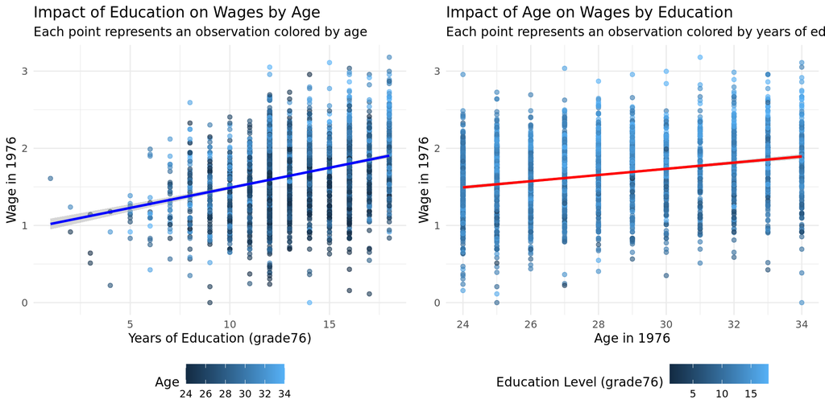

Figure 9:Impact of Continuous Variables on Wages

```r
plot_grade76 <- ggplot(df_clean, aes(x = grade76, y = wage76)) +
  geom_point(aes(color = age76), alpha = 0.6) +
  geom_smooth(method = "lm", color = "blue", se = TRUE) +
  labs(title = "Impact of Education on Wages by Age",
       subtitle = "Each point represents an observation colored by age",
       x = "Years of Education (grade76)",
       y = "Wage in 1976",
       color = "Age") +
  theme_minimal() +
  theme(legend.position = "bottom")

# Create a scatter plot of age76 vs. wage76 with a regression line
plot_age76 <- ggplot(df_clean, aes(x = age76, y = wage76)) +
  geom_point(aes(color = grade76), alpha = 0.6) +
  geom_smooth(method = "lm", color = "red", se = TRUE) +
  labs(title = "Impact of Age on Wages by Education",
       subtitle = "Each point represents an observation colored by years of education",
       x = "Age in 1976",
       y = "Wage in 1976",
       color = "Education Level (grade76)") +
  theme_minimal() +
  theme(legend.position = "bottom")
library(gridExtra)
grade76_plot <- grid.arrange(plot_grade76, plot_age76, ncol = 2)
```

```r
ggsave("grade76_plot.png", plot = grade76_plot, width = 10, height = 5, dpi = 300)
```

These visual aids Figure 9:Impact of Continuous Variables on Wages are crucial for demonstrating how incremental changes in age and education relate to changes in wages, providing a compelling argument for the continuous benefits of education.

### Implications and Future Directions

This analysis provides valuable insights for policymakers and educational institutions, suggesting that enhancing access to education can lead to significant economic benefits. Future research could explore the long-term trends in these variables or investigate other factors that might influence wages, such as technological changes or economic conditions.

In conclusion, the detailed examination of the Return to School dataset using LASSO regression offers actionable insights that could significantly influence future educational investments and economic policy planning. Our study confirms the powerful impact of demographic factors on wages and sets the stage for further research in this vital area.

## References

Belloni, A., and V. Chernozhukov. 2013. “Least Squares After Model Selection in High-Dimensional Sparse Models.” *Bernoulli* 19 (2): 521–47.

Chintalapudi, N., and et al. 2022. “LASSO Regression Modeling on Prediction of Medical Terms Among Seafarers’ Health Documents Using Tidy Text Mining.” *Bioengineering* 9 (1): 47.

Efron, B., T. Hastie, I. Johnstone, and R. Tibshirani. 2004. “Least Angle Regression.” *Annals of Statistics* 32 (2): 407–99. https://projecteuclid.org/euclid.aos/1083178935.

Fan, J., and J. Lv. 2011. “Nonconcave Penalized Likelihood with NP-Dimensionality.” *IEEE Transactions on Information Theory* 57 (8): 5467–84. https://ieeexplore.ieee.org/document/6025319.

Friedman, Jerome, Trevor Hastie, and Robert Tibshirani. 2010. “Regularization Paths for Generalized Linear Models via Coordinate Descent.” *Journal of Statistical Software* 33 (1): 1–22. https://www.jstatsoft.org/article/view/v033i01.

Hastie, Trevor, Robert Tibshirani, and Martin Wainwright. 2015. *Statistical Learning with Sparsity: The Lasso and Generalizations*. CRC Press. https://www.crcpress.com/9781498712163.

Hastie, T., R. Tibshirani, and J. Friedman. 2009. “The Elements of Statistical Learning: Data Mining, Inference, and Prediction.” *Springer Series in Statistics*. https://link.springer.com/book/10.1007/978-0-387-84858-7.

James, Gareth, Daniela Witten, Trevor Hastie, and Robert Tibshirani. 2013. *An Introduction to Statistical Learning: With Applications in r*. New York: Springer.

Li, Y., and et al. 2022. “Applying Logistic LASSO Regression for the Diagnosis of Atypical Crohn’s Disease.” *Scientific Reports* 12: 12345.

McEligot, Archana J. et al. 2020. “Logistic LASSO Regression for Dietary Intakes and Breast Cancer.” *Nutrients* 12 (9): 2652. https://www.mdpi.com/2072-6643/12/9/2652.

Meinshausen, N., and P. Bühlmann. 2006. “High-Dimensional Graphs and Variable Selection with the Lasso.” *Annals of Statistics* 34 (3): 1436–62. https://projecteuclid.org/euclid.aos/1152540754.

Musoro, et al., J. Z. 2014. “Validation of Prediction Models Based on Lasso Regression with Multiply Imputed Data.” *BMC Medical Research Methodology*.

Muthukrishnan, R., and R. Rohini. 2016. “LASSO: A Feature Selection Technique in Predictive Modeling for Machine Learning.” https://doi.org/10.1109/ICACA.2016.7887916.

Park, M. Y., and T. Hastie. 2008. “Penalized Logistic Regression for Detecting Gene Interactions.” *Biostatistics* 9 (1): 30–50.

Simon, N., and et al. 2013. “Regularization Paths for Cox’s Proportional Hazards Model via Coordinate Descent.” *Journal of Statistical Software* 39 (5): 1–13.

Tibshirani, Robert. 1996. “Regression Shrinkage and Selection via the Lasso.” *Journal of the Royal Statistical Society. Series B (Methodological)* 58 (1): 267–88. https://www.jstor.org/stable/2346178.

———. 2021. “Regression Shrinkage and Selection via the Lasso: A Retrospective.” *Journal of the Royal Statistical Society: Series B*. https://rss.onlinelibrary.wiley.com/doi/10.1111/rssa.12356.

Wang, S., and et al. 2017. “Predicting Ship Fuel Consumption Based on LASSO Regression.” *Marine Pollution Bulletin* 119 (1): 145–54.

Yiming Lu, Y. Z. 2011. “A Lasso Regression Model for the Construction of microRNA-Target Regulatory Networks.” *Bioinformatics*, 2406–13.

Zhao, P., and B. Yu. 2006. “On Model Selection Consistency of Lasso.” *Journal of Machine Learning Research* 7: 2541–63. http://www.jmlr.org/papers/volume7/zhao06a/zhao06a.pdf.

Zhou, C., and et al. 2022. “Influencing Factors of the High-Quality Economic Development in China Based on LASSO Model.” *Energy Reports* 8: 1055–65.